Queremos ilustrar o impacto da Covid-19 nas estatísticas de Síndrome Respiratória Aguda Grave (SRAG). Para isso, temos os dados da SRAG no estado de SP no ano de 2019 e os dados da SRAG no estado até o começo de Agosto deste ano.

Sobre a SRAG temos este trecho do boletim epidemiológico feito pelo Núcleo de Vigilância Epidemiológica Hospitalar com a Santa Casa de Misericórdia de Goiânia: “Dentre os principais agentes etiológicos que resultam em SRAG, estão os vírus (influenza A, dengue, vírus sincicial respiratório, adenovírus, hantavírus e coronavírus), e outros agentes (pneumococos,outrasbactérias, Legionella sp., leptospirose, etc.) … Considera-se caso suspeito de SRAG todos os indivíduos de qualquer idade com doença respiratória aguda caracterizada por febre superior a 38ºC, tosse e dispneia, acompanhadas ou não de dor de garganta ou manifestações gastrointestinais. Além disso, devem ser observados os seguintes sinais e sintomas: aumento d afrequência respiratória (>25 rpm) e hipotensão em relação à pressão arterial habitual do paciente. Em crianças, acrescentam-se os seguintes sintomas: batimentos de asa de nariz, cianose, tiragem intercostal,desidratação e inapetência”

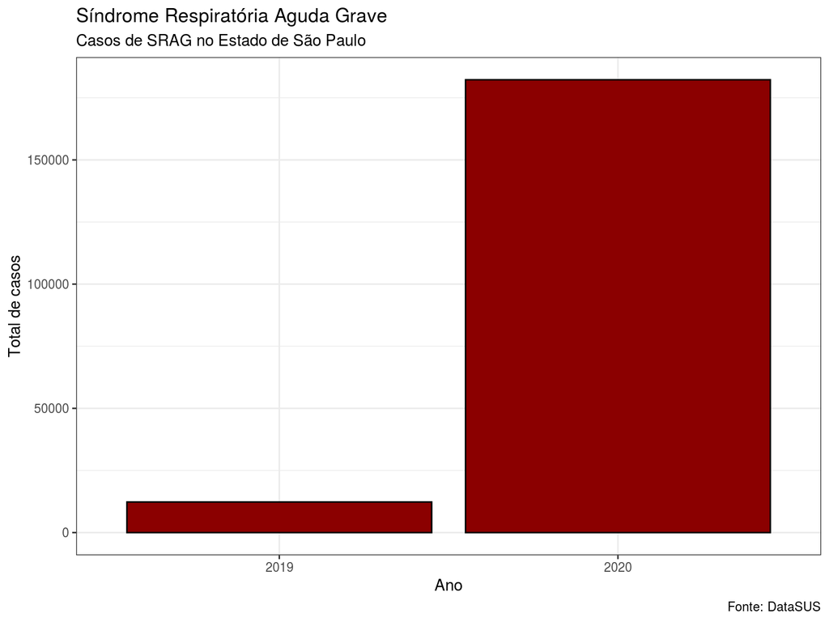

Existe um aumento descomunal no número de complicações por causas respiratórias no estado de São Paulo - e em todo Brasil, para ser mais exato - e nem chegamos ao final de 2020, definitivamente o termo “gripezinha” (ilação do presidente, inclusive) não reflete a gravidade do problema que estamos enfrentando.

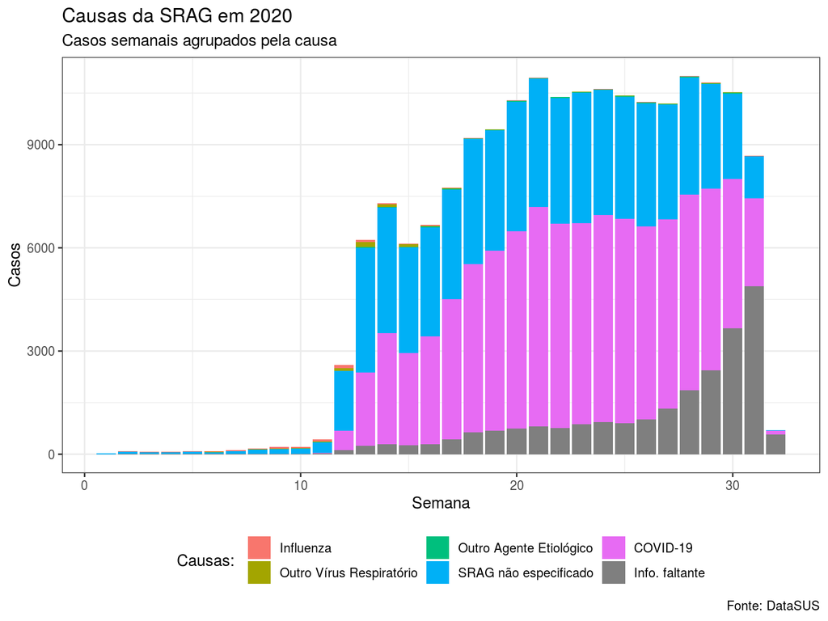

Podemos ver claramente a influência da Covid-19 na contabilização dos casos, sem contar que temos nesta classificação ainda SRAG não especificado (o Brasil tem uma taxa baíxissima de testes, média de 2,28 para cada 100 mil habitantes [1]) e temos dados faltantes no preenchimento da ficha.

Uma (infelizmente) velha conhecida dos brasileiros é a dengue, abaixo uma simples comparação simplesmente para não deixar dúvidas que a arbovirose é bem menos letal que a Covid-19. Enquanto a dengue tem uma letalidade registrada de aproximadamente 0,05% no estado de São Paulo, a doença resultante do novo coronavírus tem uma letalidade em torno de 3%.

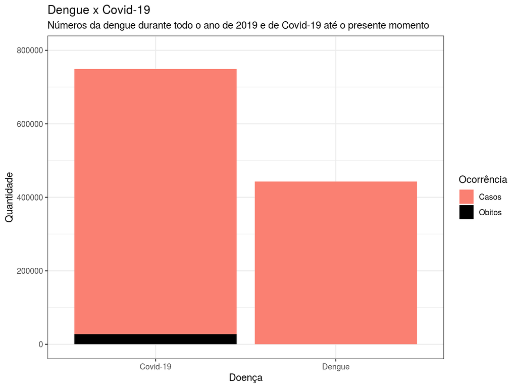